# Tema 06 - Regularización

Ridge regression y LASSO

Pedro Albarrán

Dpto. de Fundamentos del Análisis Económico. Universidad de Alicante

Henry Redondo

# Muchas variables

## El problema: muchas variables candidatas

- Escenario típico en economía y empresa: predecir ventas, salarios o abandonos de clientes con muchas variables, interacciones y polinomios
- El problema es elegir las variables relevantes, porque más variables hacen el modelo más complejo (Tema 05):
  - menos sesgo, pero más varianza
  - si es demasiado complejo, **sobreajusta**: error bajo en entrenamiento y alto en prueba
- Para comparar modelos hay que estimar el error de prueba:
  - **directamente**, con validación cruzada: costosa en cálculo, y cada estimación usa menos datos
  - **indirectamente**, añadiendo un ajuste por número de parámetros $k$ al error de entrenamiento: $R^2$ ajustado, AIC o BIC
    $$\small
    AIC = \frac{1}{n}\left(SCR + 2k\,\widehat{\sigma}^2\right) \qquad
    BIC = \frac{1}{n}\left(SCR + \log(n)\, k\,\widehat{\sigma}^2\right)$$
    donde $\widehat{\sigma}^2$ es la varianza estimada del error
- Seleccionar así exige estimar y comparar $2^k$ modelos, uno por combinación de variables. La **regularización** estima un solo modelo con todas

## Los datos: la tienda con un modelo flexible

- Volvemos a los **404 clientes** de `tienda` del Tema 05: el gasto anual (`ventas`) y sus seis variables candidatas
- En la práctica 3 del Tema 05 probábamos formas a mano; ahora una fórmula las incluye todas:
  - polinomios de grado 4 en `edad` y en `log(renta)`, y una columna por nivel de estudios con `factor(educ)`
  - con `( ... )^2`, todas las interacciones de dos en dos

```r
tienda <- read_csv("data/tienda.csv") |>
  mutate(zona = factor(zona, levels = c("pueblo", "ciudad", "capital")))
formula <- ventas ~ (poly(edad, 4) + poly(log(renta), 4) +
                       factor(educ) + mujer + descuento + zona)^2
```

- Son **143 coeficientes**, más la constante, para 404 clientes: todos tienen sentido a priori, y muchos sobrarán

# Regularización en regresión

## ¿Qué es la regularización?

- MCO elige los coeficientes que minimizan la SCR. La **regularización** le suma una **penalización** por el tamaño de los coeficientes:

  $$\min_{\beta}\ SCR(\beta) + \lambda \, P(\beta)$$
  - $P(\beta)$ mide el tamaño de los coeficientes
  - $\lambda \geq 0$ es el peso de la penalización (de momento, lo tomamos como dado)
  - la constante (la media de $Y$) no se penaliza: solo el efecto de las $X$
- Castigar los coeficientes grandes simplifica el modelo: más sesgo y menos varianza, pero puede compensar cuando MCO sobreajusta (p. ej., con muchas variables)
  - con $\lambda = 0$ es MCO
  - al subir $\lambda$, los coeficientes se encogen hacia cero
- Frente a seleccionar variables, se estima **un solo modelo con todas ellas** para cada valor de $\lambda$
- Está orientada a **predecir**: los coeficientes están sesgados hacia cero a propósito y no sirven para afirmar nada sobre el impacto de cambiar una $X$ sobre $Y$ (y menos su efecto causal)

## Ridge regression y LASSO

**Ridge regression**

$$\small P(\beta) = \sum_{j=1}^{k}\beta_j^2$$

- Penaliza la suma de los **cuadrados**
- Encoge los coeficientes hacia cero, pero ninguno llega a cero $\Rightarrow$ todas las variables se mantienen
- Funciona mejor si muchas variables aportan algo

**LASSO** (*least absolute shrinkage and selection operator*)

$$\small P(\beta) = \sum_{j=1}^{k}|\beta_j|$$

- Penaliza la suma de los **valores absolutos**
- Encoge los coeficientes, y algunos llegan **exactamente a cero**
- Funciona mejor si pocas variables importan y muchas sobran $\Rightarrow$ modelo más interpretable
- La **red elástica** combina las dos eligiendo un peso $\alpha$ entre 0 y 1: $\ \small \lambda\left[\alpha \sum_j |\beta_j| + (1-\alpha) \sum_j \beta_j^2\right]$
- LASSO selecciona variables: alternativa a los contrastes de significatividad (sin formalización estadística)
- Para hablar de efectos, se reestima por MCO o logit (u otro método, si pensamos que no se cumple $E(u|X) = 0$) solo con las variables que elige LASSO (**post-LASSO**)
  - elegir variables y estimar con los mismos datos es como trabajar sin muestra de prueba: entre otros problemas de fiabilidad, los p-valores salen demasiado optimistas
  - por eso, en la práctica, se usan versiones más elaboradas

## Estandarizar las variables

- MCO es **equivariante a escala**: si una variable cambia de unidades (p. ej., a miles de euros = euros/1.000), su coeficiente se reescala en sentido contrario (×1.000) $\Rightarrow$ las predicciones y la SCR no cambian
- Con regularización, la función objetivo (SCR + penalización) **sí depende de las unidades**:
  - al reescalar el coeficiente, la SCR no cambia, pero la penalización sí
  - la penalización recompensa coeficientes cercanos a cero, y eso depende de las unidades: con la renta en miles, el mismo efecto tiene un coeficiente 1.000 veces mayor y se castiga más
  - por eso cambia toda la solución, también las predicciones
- Para castigar a todos los coeficientes por igual, deben estar en la **misma escala**: antes de regularizar, se **estandarizan** las variables explicativas, para que todas tengan media 0 y desviación típica 1:

$$\Large \tilde{x}_{ij} = \dfrac{x_{ij} - \bar{x}_j}{\text{sd}(x_j)}$$

## Ridge regression y LASSO en R: `glmnet()`

- `glmnet()` estima Ridge regression y LASSO. A diferencia de `lm()`, no usa una fórmula: pide las variables explicativas en una matriz `x` y la respuesta en un vector `y`
- `model.matrix()` construye esa matriz a partir de la fórmula, con una columna por cada término:

```r
x <- model.matrix(formula, data = tienda)
y <- tienda$ventas
```

- En `glmnet(x, y, alpha, lambda)`:
  - `alpha = 1` es LASSO y `alpha = 0`, Ridge regression
  - `lambda` es el peso de la penalización
  - estandariza las variables por defecto (`standardize = TRUE`) y devuelve los coeficientes en las unidades originales
- Después de estimar, `coef()` da los coeficientes para cada valor de $\lambda$

## Elegir el hiperparámetro $\lambda$

- Dado un $\lambda$, estimamos los parámetros $\beta$ que mejor ajustan a los datos, minimizando la SCR penalizada
- $\lambda$ es un **hiperparámetro**: un parámetro especial que se elige con los datos, pero aparte del resto de parámetros
  - el peso $\alpha$ de la red elástica es otro hiperparámetro
- ¿Cómo elegimos $\lambda$ en la regularización?
  1. se fija una rejilla de valores de $\lambda$
  2. para cada uno, se calcula el error medio mediante validación cruzada
  3. se selecciona el $\lambda^*$ con menor error medio (probando varios rangos hasta encontrar la forma de U)
  4. se vuelve a ajustar el modelo con $\lambda^*$ en toda la muestra de entrenamiento
  5. se evalúa en la muestra de prueba, nunca usada antes
- **Regla de un error estándar**: cuando varios $\lambda$ tienen un error medio (estimado) indistinguible, es decir, dentro de un error estándar, se elige el mayor, porque entre modelos similares se prefiere el más simple

## Elegir $\lambda$ en R: `cv.glmnet()`

- `cv.glmnet()` hace los cuatro primeros pasos con 100 valores de $\lambda$ (por defecto) y `nfolds` bloques de validación cruzada
- LASSO con el modelo flexible:

```r
set.seed(12345678)
cv <- cv.glmnet(x, y, alpha = 1, nfolds = 10)
plot(cv, ylim = c(100000, 400000))
```

- El gráfico muestra el error (MSE) de validación cruzada frente a $-\log(\lambda)$, como en el Tema 05: más a la izquierda, mayor $\lambda$ y más regularización<sup>1</sup>

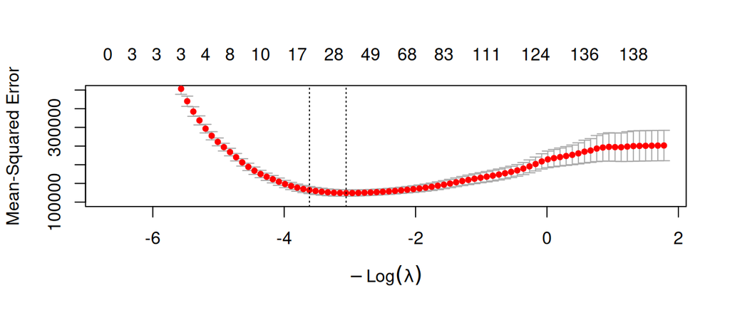

- Cada punto rojo es el error medio de un $\lambda$, y su barra, $\pm$ un error estándar
- Las líneas verticales marcan `lambda.min` (menor error) y `lambda.1se` (regla de un error estándar)
- `cv$cvm` guarda el error medio de cada $\lambda$ de `cv$lambda`
[^1]: Arriba aparecen las columnas que quedan con cada $\lambda$.

## PRÁCTICA en clase (1): la forma del gasto

Con vuestro DNI como semilla:

1. Con el modelo lineal `ventas ~ log(renta) + edad + mujer + factor(educ) + descuento + zona`, ajustad LASSO y Ridge regression con `lambda = c(200, 50, 0)` y mirad `coef()`. ¿Qué da $\lambda = 0$? ¿Qué pasa al subir $\lambda$? ¿Cuáles llegan a cero?
2. Con el modelo flexible de la tienda (polinomios e interacciones de todas las variables), elegid $\lambda$ en LASSO con `cv.glmnet()`. ¿Cuántas columnas quedan con `lambda.min` y con `lambda.1se`?
3. Con el modelo flexible, comparad el error de MCO, Ridge regression y LASSO con la misma semilla

**Nota**

**Ahora el ejercicio: entrega 1, apartados a) a c).**

# Regularización en clasificación

## Los datos: el abandono de clientes

- `churn_clientes.csv` son **600 clientes** de un servicio de suscripción. `churn` dice si abandonaron (`Sí` o `No`), y las candidatas son señales que a priori podrían anunciarlo:
  - uso del servicio, pago, soporte y satisfacción, competencia
  - la empresa cliente (tamaño, sector, país) y datos del registro (día, navegador, dispositivo)
- Quitamos el identificador y `plan_tipo`, que repite `precio_mensual`. El punto de `churn ~ .` pone todas las demás columnas como explicativas, y `glmnet` quiere la respuesta como factor

```r
churn <- read_csv("data/churn_clientes.csv") |>
  select(-id_cliente, -plan_tipo)
xc <- model.matrix(churn ~ ., data = churn)
yc <- factor(churn$churn)
set.seed(12345678)
cv_logit <- cv.glmnet(xc, yc, family = "binomial", alpha = 1,
                      type.measure = "auc", nfolds = 10)
```

- Cambian dos cosas: `family = "binomial"` estima un logit por verosimilitud (se minimiza la **desviación** más la penalización de los coeficientes), y `type.measure = "auc"` elige $\lambda$ por el AUC (Tema 05)

## PRÁCTICA en clase (2): señales de abandono

La empresa quiere saber, con lo que conoce de cada cliente, cuáles tienen más probabilidad de irse. Con `churn` y vuestro DNI como semilla:

1. Ajustad LASSO y Ridge regression con `cv.glmnet()`, dibujad el AUC frente a $\lambda$ y comparadlos. Para vigilar a los clientes, ¿qué lista corta de señales de alarma daríais? ¿Compensa quedarse con menos variables?
2. A los clientes con más riesgo se les puede ofrecer $k$ meses gratis, lo que supone para la empresa perder $k$ meses de cuota. Si un cliente abandona, la pérdida es un año de cuota, así que la oferta compensa si su probabilidad de abandono $p$ cumple $12\,p > k$.
   1. ¿Cuántos meses gratis, como máximo, compensa ofrecer a un cliente con $p = 0{,}7$?
   2. Usando `predict(..., type = "response")` con el modelo del punto 1 para obtener la probabilidad predicha de abandono de cada cliente de la muestra, ¿a cuántos clientes haríais una oferta de 6 meses?

La empresa también estudia medidas para subir la satisfacción de sus clientes y así evitar que se vayan. Como estas medidas son costosas, quiere saber cuánto compensa gastarse en ellas:

3. Estimad con `glm()` un logit con las variables que deja `lambda.1se` (post-LASSO). Considerando de nuevo que, si un cliente se va, la pérdida es un año de cuota (12 × `precio_mensual`), ¿cuánto le compensa gastar a la empresa por cliente para subir su satisfacción un punto? Pista: ¿cuánto cambia la probabilidad de abandono si la satisfacción sube un punto? Discutid si se puede interpretar esa cifra como el efecto de un cambio en la satisfacción

**Nota**

**Ahora el ejercicio: entrega 2, apartados a) a c).**